Name: Aditya Sagave

Student no: 47541164

GLM STAT8111 - Assignment 1

## Q1

```r
data(cystfibr)
head(cystfibr)
```

|  | age | sex | height | weight | bmp | fev1 | rv | frc | tlc | pemax |
| --- | --- | --- | --- | --- | --- | --- | --- | --- | --- | --- |
| 1 | 7 | 0 | 109 | 13.1 | 68 | 32 | 258 | 183 | 137 | 95 |
| 2 | 7 | 1 | 112 | 12.9 | 65 | 19 | 449 | 245 | 134 | 85 |
| 3 | 8 | 0 | 124 | 14.1 | 64 | 22 | 441 | 268 | 147 | 100 |
| 4 | 8 | 1 | 125 | 16.2 | 67 | 41 | 234 | 146 | 124 | 85 |
| 5 | 8 | 0 | 127 | 21.5 | 93 | 52 | 202 | 131 | 104 | 95 |
| 6 | 9 | 0 | 130 | 17.5 | 68 | 44 | 308 | 155 | 118 | 80 |

```r
# Select the variables of interest
variables_of_interest <- cystfibr[c("weight", "sex", "bmp", "fev1", "rv", "age", "frc")]

# Calculate correlation matrix
correlation_matrix <- cor(variables_of_interest)
correlation_matrix
```

```
##            weight        sex        bmp       fev1         rv        age
## weight  1.0000000 -0.1904400  0.6725463  0.4488393 -0.6215056  0.9058675
## sex    -0.1904400  1.0000000 -0.1375611 -0.5282571  0.2713516 -0.1671220
## bmp     0.6725463 -0.1375611  1.0000000  0.5455204 -0.5823729  0.3777643
## fev1    0.4488393 -0.5282571  0.5455204  1.0000000 -0.6658557  0.2944880
## rv     -0.6215056  0.2713516 -0.5823729 -0.6658557  1.0000000 -0.5519445
## age     0.9058675 -0.1671220  0.3777643  0.2944880 -0.5519445  1.0000000
## frc    -0.6172561  0.1836055 -0.4343888 -0.6651149  0.9106029 -0.6393569
##               frc
## weight -0.6172561
## sex     0.1836055
## bmp    -0.4343888
## fev1   -0.6651149
## rv      0.9106029
## age    -0.6393569
## frc     1.0000000
```

```r
# Create scatter plot matrix
#ggpairs(variables_of_interest)
```

**Answer 1.a:**

#### **Positive correlations:

- Weight and fev1, Weight and age, rv and frc

#### Negative correlation:

- Weight and rv, weight and frc, fev1 and rv, fev1 and frc, rv and age, age and frc

**Answer 1.b:** #### **Numerical Analysis:**

- Weight and FEV1:positive correlation (0.45); Age and RV: Moderate negative correlation (-0.55); FEV1 and RV: Strong negative correlation (-0.67); Weight and Age: Very strong positive correlation (0.91); RV and FRC: Strong positive correlation (0.91); residual volume (RV) and functional residual capacity (FRC) are closely related. FEV1 and FRC: Strong negative correlation (-0.67)

### Linear Model for Relationship between Weight and Pemax:

The linear model to study the relationship between the response variable Pemax (maximum expiratory pressure) and the explanatory variable Weight can be expressed as:

$$y(pemax) =
\beta_0+\beta_1x(weight)+\epsilon$$
$Where,$

$\text{Pemax is the response variable (maximum expiratory pressure).}$

$x\text{(Weight) is the co-variate.}$

$\beta_0\text{ is the intercept}$

$\beta_1\text{ is the Slopw OR coefficient for Weight, representing the change in Pemax for a unit change in weight.}$

$\epsilon\text{ is the error term, representing the variability not explained by the model.}$

#### Assumptions of the Linear Model:

- **Linearity**: The relationship between Weight and Pemax is assumed to be linear.
- **Independence**: The errors ($\epsilon$) are assumed to be independent for each observation.
- **Multicollinearity**: There is no perfect multicollinearity among the predictor variables.
- **Normality of Errors**: The errors are assumed to be normally distributed.

#### Model Fitting and Interpretation:

The linear model was fitted to the data to quantify the relationship between Pemax and Weight. The coefficients were estimated, with the results indicating that the intercept ($\beta_0$) represents the estimated Pemax when Weight is zero, which might not be meaningful in this context. The coefficient for Weight ($\beta_1$) represents the change in Pemax for a unit change in weight.

```r
model1 <- lm(pemax ~ weight, data = cystfibr)
summary(model1)
```

```
##
## Call:
## lm(formula = pemax ~ weight, data = cystfibr)
##
## Residuals:
##    Min     1Q Median     3Q    Max
## -44.30 -22.69   2.23  15.91  48.41
##
## Coefficients:
##             Estimate Std. Error t value Pr(>|t|)
## (Intercept)  63.5456    12.7016   5.003 4.63e-05 ***
## weight        1.1867     0.3009   3.944 0.000646 ***
## ---
## Signif. codes:  0 '***' 0.001 '**' 0.01 '*' 0.05 '.' 0.1 ' ' 1
##
## Residual standard error: 26.38 on 23 degrees of freedom
## Multiple R-squared:  0.4035, Adjusted R-squared:  0.3776
## F-statistic: 15.56 on 1 and 23 DF,  p-value: 0.0006457
```

$$pemax = 63.5456+
1.1867*weight$$

- $\beta_0 = 63.5456$
- $\beta_1 = 1.1867$
- Both the intercept and weight coefficient are statistically significant (p < 0.001), indicating that they have a significant impact on the model.
- The multiple R-squared value (0.4035) indicates that approximately 40.35% of the variability in Pemax can be explained by the linear relationship with weight.
- The adjusted R-squared (0.3776) considers the number of predictors and provides a more realistic estimate of the model’s explanatory power.

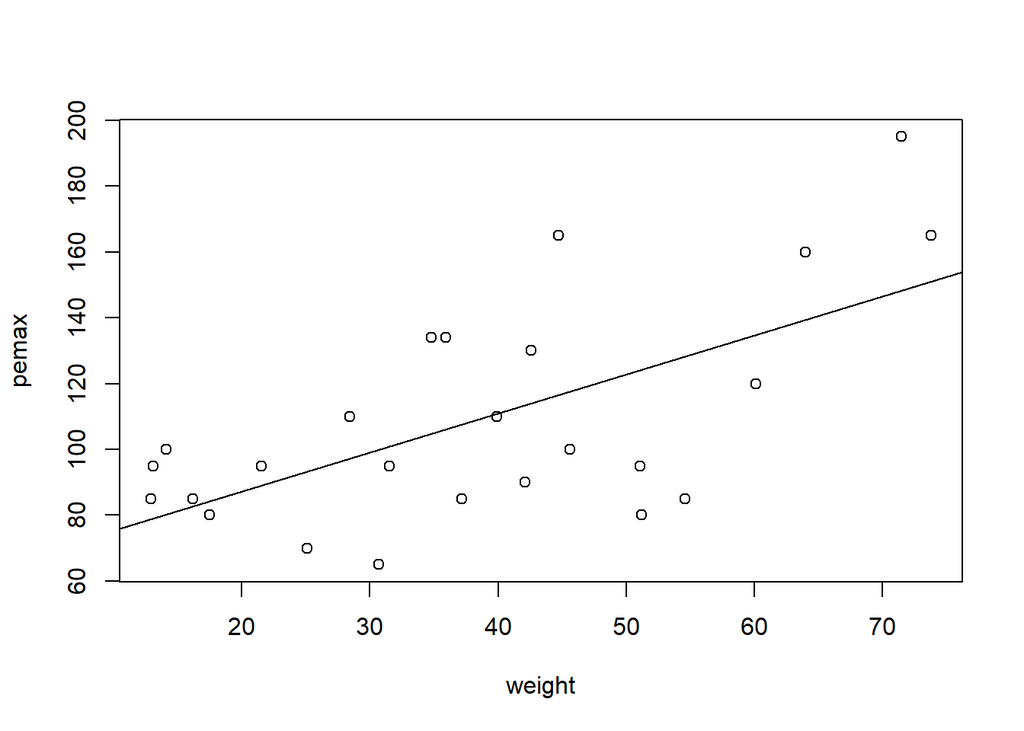

```r
plot(pemax ~ weight, data = cystfibr)
abline(model1)
```

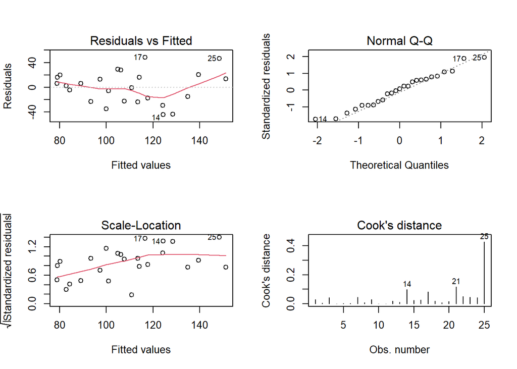

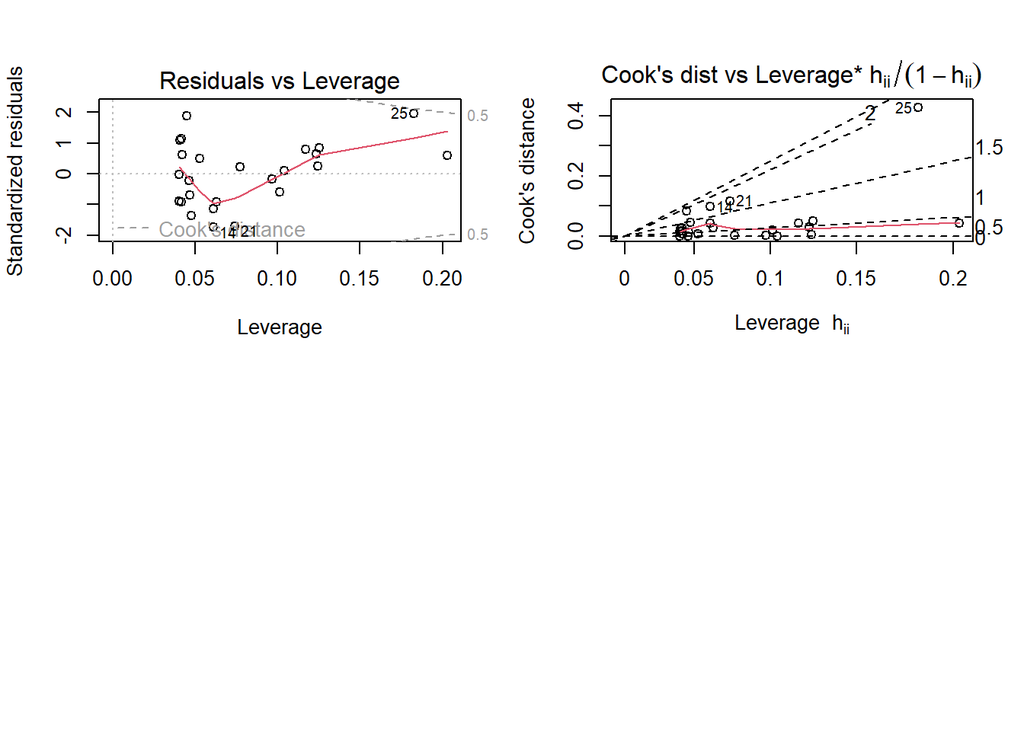

```r
par(mfrow = c(2, 2))
plot(model1, which = 1:6)
```

#### Diagnostic plots interpretations:

- **Residuals vs Fitted Plot**: The Residuals are randomly scattered along the zero ($y = 0$) line without any clear funnel-like shape or patterns.
- **Normal Q-Q Plot**: Residuals follow a straight line, indicating normality, except 3 outliers (14, 17, 25).
- **Residuals vs Leverage Plot**: Except a residual of 25 is close to the 0.5 dashed line, no points exceeding it indicate that there are no influential observations significantly impacting the model.
- **Cook’s Distance Plot**: None of the points surpass the Cook’s threshold of 1, implying that there are no influential observations significantly affecting the model.

**Answer 1.c:**

Model 1 - Including Sex as a Categorical Variable:

$$pemax = \beta_0 + \beta_1*weight +
\beta_2*sex + \epsilon$$

- The coefficient $\beta_2$ represents the change in pemax when sex changes from male (0) to female (1), while keeping weight constant.

Model 2 - Interaction Model with Sex:

$$pemax = \beta_0 + \beta_1*weight +
\beta_2*sex + \beta_3*(weight*sex) + \epsilon$$

- The interaction term $\beta_3$ represents how the relationship between Weight and pemax changes depending on the sex. It indicates whether the effect of weight on pemax differs between males and females.

```r
model2 <- lm(pemax ~ weight + sex, data = cystfibr)
model3 <- lm(pemax ~ weight * sex, data = cystfibr)

summary(model2)
```

```
##
## Call:
## lm(formula = pemax ~ weight + sex, data = cystfibr)
##
## Residuals:
##     Min      1Q  Median      3Q     Max
## -47.388 -16.850   0.073  13.168  43.748
##
## Coefficients:
##             Estimate Std. Error t value Pr(>|t|)
## (Intercept)  70.9719    14.4644   4.907 6.61e-05 ***
## weight        1.1248     0.3056   3.681  0.00131 **
## sex         -11.4776    10.7963  -1.063  0.29926
## ---
## Signif. codes:  0 '***' 0.001 '**' 0.01 '*' 0.05 '.' 0.1 ' ' 1
##
## Residual standard error: 26.31 on 22 degrees of freedom
## Multiple R-squared:  0.4327, Adjusted R-squared:  0.3811
## F-statistic: 8.388 on 2 and 22 DF,  p-value: 0.00196
```

```r
summary(model3)
```

```
##
## Call:
## lm(formula = pemax ~ weight * sex, data = cystfibr)
##
## Residuals:
##     Min      1Q  Median      3Q     Max
## -50.464 -14.565  -2.096  14.247  42.973
##
## Coefficients:
##             Estimate Std. Error t value Pr(>|t|)
## (Intercept)  61.3603    15.9335   3.851 0.000927 ***
## weight        1.3572     0.3471   3.910 0.000805 ***
## sex          22.0905    27.2923   0.809 0.427358
## weight:sex   -0.9240     0.6922  -1.335 0.196187
## ---
## Signif. codes:  0 '***' 0.001 '**' 0.01 '*' 0.05 '.' 0.1 ' ' 1
##
## Residual standard error: 25.85 on 21 degrees of freedom
## Multiple R-squared:  0.477,  Adjusted R-squared:  0.4023
## F-statistic: 6.385 on 3 and 21 DF,  p-value: 0.003025
```

Analysis of models:

Choice and Justification:

Amongst Model 1, Model 2, and Model 3, Model 3 stands out with the highest Adjusted R-squared value, which is 0.4023. This suggests that Model 3 explains approximately 40.23% of the variability in Pemax using the combination of weight, sex, and their interaction. While Model 2 and Model 3 both include the sex predictor, Model 3’s higher Adjusted R-squared indicates a potentially better fit.

**Answer 1.d:**

**Diagnostic**: For Diagnostic we assume the same factore that we assumed for the linear model earlier. These are Linearity, Independence, Multicollinearity & Normality of Errors

**Final model equation**:

$$pemax = \beta_0 + \beta_1*weight +
\beta_2*bmp + \beta_3*fev1 + \beta_4*rv + \beta_5*frc +
\epsilon$$

```r
model4 <- lm(pemax ~ weight + bmp + fev1 + rv + frc, data = cystfibr)
summary(model4)
```

```
##
## Call:
## lm(formula = pemax ~ weight + bmp + fev1 + rv + frc, data = cystfibr)
##
## Residuals:
##    Min     1Q Median     3Q    Max
## -39.72 -12.17   4.83  15.29  34.75
##
## Coefficients:
##             Estimate Std. Error t value Pr(>|t|)
## (Intercept) 64.18640   54.73550   1.173 0.255423
## weight       1.73556    0.42529   4.081 0.000637 ***
## bmp         -1.35105    0.66763  -2.024 0.057303 .
## fev1         1.53087    0.62948   2.432 0.025078 *
## rv           0.13612    0.15668   0.869 0.395787
## frc         -0.02477    0.31278  -0.079 0.937703
## ---
## Signif. codes:  0 '***' 0.001 '**' 0.01 '*' 0.05 '.' 0.1 ' ' 1
##
## Residual standard error: 23.34 on 19 degrees of freedom
## Multiple R-squared:  0.6142, Adjusted R-squared:  0.5127
## F-statistic:  6.05 on 5 and 19 DF,  p-value: 0.001637
```

$$pemax = 64.18 + 1.73*weight -1.35*bmp +
1.53*fev1 + 0.13*rv -0.02*frc + \epsilon$$

**Interpretation of Model Parameters:**

- $\beta_0$: The baseline Pemax value when all predictors are zero.
- $\beta_1$: A unit increase in weight corresponds to a change of 1.7356 in Pemax, holding other factors constant.
- $\beta_2$: A unit increase in bmp relates to a decrease of 1.3511 in Pemax, though this effect is marginally significant.
- $\beta_3$: A unit increase in fev1 results in a change of 1.5309 in Pemax, with other predictors unchanged.
- $\beta_4$: The effect of rv (0.1361) on Pemax is not statistically significant (p > 0.05).
- $\beta_5$: The effect of frc (-0.0248) on Pemax is not statistically significant (p > 0.05).
- $\epsilon$: The vector of residual errors associated with each data point that the model doesn’t perfectly explain.

## Q2

**Answer 2.a:**

The General exponential distribution is represented as :

$$f(y|\theta,\phi) =
exp\biggr(\frac{y\theta=b(\theta)}{a(\theta)}+c(y,\theta)\biggr)$$

Given Inverse Gaussian distribution is:

$$f(y|\mu,\gamma) =
\sqrt{\frac{\gamma}{2(\pi)x^3}}exp\biggr(-\frac{\gamma(x-\mu)^2}{2\mu^2x}\biggr)$$
$$f(y|\mu,\gamma) =
exp\biggr(-\frac{1}{2}log(\frac{2(\pi)x^3}{\gamma})-\frac{\gamma(x^2-2x\mu+\mu^2)}{2\mu^2x}\biggr)$$

$$f(y|\mu,\gamma) =
exp\biggr(-\frac{\gamma(x^2)}{2\mu^2x}-\frac{\gamma\mu^2}{2\mu^2x}+\frac{\gamma\mu(x)}{2\mu^2x}-\frac{1}{2}log(\frac{2(\pi)x^3}{\gamma})\biggr)$$

$$f(y|\mu,\gamma) =
exp\biggr(x\gamma\frac{\mu-\frac{1}{2}\mu^2}{2\mu^2x}-\frac{1}{2}\biggr[\frac{\gamma(x^2)}{\mu^2x}log(\frac{2(\pi)x^3}{\gamma})\biggr]\biggr)$$

Here, $\theta = \mu, \phi=2\mu^2x$

Putting these values back in the inverse gaussian distribution we get,

$$exp\biggr(\frac{\gamma(x)\theta-\frac{1}{2}\theta^2}{\phi}-\frac{1}{2}\biggr[\frac{\gamma(x^2)}{\phi}+log\biggr(\frac{2(\pi)x^3}{\gamma}\biggr)\biggr]\biggr)$$

Here,

$a(\theta)=\phi, b(\theta)=\frac{1}{2}\theta^2$

$c(y,\phi)=-\frac{1}{2}\biggr[\frac{\gamma(x^2)}{\phi}+log\biggr(\frac{2(\pi)x^3)}{\gamma}\biggr)\biggr]$

The natural parameter is $\theta = \mu$

**Answer 2.a:** (By other method)

The Inverse Gaussian distribution can be shown to be a member of the exponential family by expressing it in the general form:

$$f(x; \theta) = h(x) \cdot \exp\left(
\frac{T(x) \cdot \theta - A(\theta)}{\phi} \right)$$

Where:

$f(x;\theta)$ is the probability density function (PDF) of the distribution.

$\theta$ is the natural parameter.

$h(x)$ is the base measure.

$T(x)$ is the sufficient statistic.

$A(\theta)$ is the log partition function.

$\phi$ is the dispersion parameter.

Comparing this with the Inverse Gaussian PDF:

$$f(x; \mu, \gamma) =
\sqrt{\frac{\gamma}{2\pi x^3}} \cdot \exp\left( -\frac{\gamma(x -
\mu)^2}{2\mu^2x} \right)$$

We can see that the Inverse Gaussian distribution can be written in the exponential family form with:

- Natural parameter $\theta=-\frac{\mu^2}{\gamma}$
- Sufficient statistic $T(x)=x$
- Log partition function $A(\theta)=-\frac{1}{2}log \left(\gamma \theta \right)$
- Dispersion parameter $\theta = 1$
- Base measure $h(x) = \sqrt{\frac{\gamma}{2(\pi)x^3}}$

**Answer 2.b:**

Natural and Scale Parameters: From the derived exponential family form, the natural parameter is $\theta = -\frac{\mu^2}{\gamma}$ The scale parameter is not directly present in the exponential family form for this distribution.

**Answer 2.c:**

Mean and Variance:

The mean and variance of the Inverse Gaussian distribution can be derived from the natural parameter $\theta$ and the scale parameter $\phi$

Mean: The mean ($\mu$) of the Inverse Gaussian distribution is given by $E(X) = -\frac{\partial A(\theta)}{\partial \theta} = -\frac{1}{\theta}$

Variance: The variance $\sigma^2$ of the Inverse Gaussian distribution is given by $Var(X) = \frac{\phi}{-\frac{\partial^2 A(\theta)}{\partial \theta^2}} = \frac{\phi}{\theta^3}$

Using the relation between the natural parameter $\theta$ and the distribution parameters $\mu$ and $\gamma$, we can express the mean and variance in terms of $\mu$ and $\gamma$:

- Mean: $E(X) = \mu$
- Variance: $Var(X)=\frac{\mu^3}{\gamma}$

## Q3

**Answer 3.a:**

Given linear model: $Y_i=X_i^T\beta+\epsilon_i$, where $\epsilon_i$ arr i.i.d normally distributed noise with mean 0 and variance $\sigma^2$

The likelihood function for a single observation $(X_i,X_n)$ is the probability density function (PDF) of the normal distribution:

$$f(Y_i|X_i, \beta,\sigma^2) =
\frac{1}{\sqrt{2 \pi
\sigma^2}}exp(-\frac{(Y_i-X_i^T\beta)^2}{2\sigma^2})$$

The likelihood function for all n observations ${(X_1, Y_1),...,(X_n,Y_n)}$ is the product of the individual likelihoods:

$$L(\beta|X,Y, \sigma^2)=
\prod_{i=1}^nf(Y_i|X_i,\beta,\sigma^2)$$

Taking the logarithm of the likelihood (log-likelihood) simplifies the product into a sum and is a common practice for mathematical convenience:

$$logL(\beta|X,Y,\sigma^2)=-\frac{n}{2}log(2 \pi
\sigma^2) -
\frac{1}{2\sigma^2}\Sigma_{i=1}^n(Y_i-X_i^T\beta)^2$$

The MLE of the parameter vector $\beta$ is the value that maximizes the log-likelihood, which is equivalent to minimizing the negative log-likelihood or, equivalently, minimizing the squared error loss:

$$LS(\beta) =
\frac{1}{n}\Sigma_{i=1}^n(Y_i-X_i^T\beta)^2$$

This is the same form as the squared error loss function, which is minimized when the parameter vector $\beta$ is chosen such that the observed responses $Y_i$ are as close as possible to the predicted responses $X_i^T\beta$.

In summary, the MLE for the parameter vector $\beta$ in the linear model with normally distributed noise is also the solution to the squared error loss minimization problem, commonly known as the least squares estimator.

**Answer 3.b:**

Given the Laplace distribution for the noise, the likelihood of a single observation $Y_i$ is:

$$f(Y_i|X_i, \beta, \sigma^2) =
\frac{1}{2\sigma^2}exp(-\frac{|Y_i-X_i^T\beta|}{\sigma})$$

The likelihood of the entire sample is the product of individual likelihoods:

$$L(\beta|X,Y,\sigma^2) =
\prod_{i=1}^n\frac{1}{2\sigma^2}exp(-\frac{|Y_i-X_i^T\beta|}{\sigma})$$
Taking the logarithm of the likelihood:

$$logL(\beta|X,Y,\sigma^2) =
-nlog(2\sigma)-\frac{1}{\sigma}\Sigma_{i=1}^n
|Y_i-X_i^T\beta|$$

This is the log-likelihood for the Laplace-distributed noise.

To show that maximizing the log-likelihood is equivalent to minimizing the absolute error loss (AL), notice that the term $\frac{1}{\sigma}\Sigma_{i=1}^n|Y_i-X_i^T\beta|$ is proportional to the absolute error loss. Maximizing the log-likelihood is equivalent to minimizing the negative log-likelihood, which in this case is proportional to the absolute error loss:

Thus, maximizing the log-likelihood is equivalent to minimizing the absolute error loss.

The absolute error loss (AL) is defined as:

$$AL(\beta) =
\frac{1}{n}\Sigma_{i=1}^n|Y_i-X_i^T\beta|$$

In summary, for the Laplace distribution noise, maximizing the log-likelihood is equivalent to minimizing the absolute error loss (AL), which is the sum of the absolute differences between observed responses $Y_i$ and predicted responses $X_i^T\beta$

**Answer 3.c:**

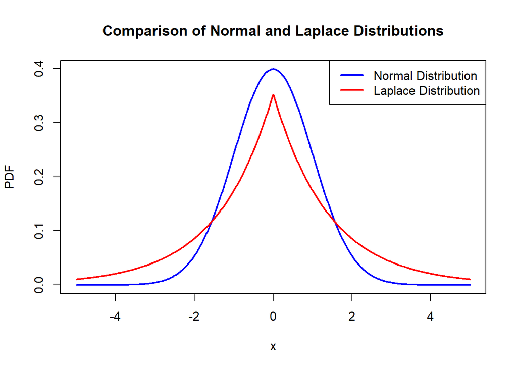

```r
# Parameters
variance <- 1 # Choose any desired variance
sigma_laplace <- sqrt(2) * sqrt(variance) # Adjusted sigma for Laplace
# Values for x
x <- seq(-5, 5, length.out = 500)

pdf_normal <- (1 / (sqrt(2 * pi) * sqrt(variance))) * exp(-x^2 / (2 * variance))
pdf_laplace <- (1 / (2 * sigma_laplace)) * exp(-abs(x) / sigma_laplace)


plot(x, pdf_normal, type = "l", col = "blue", lwd = 2, xlab = "x", ylab = "PDF",
main = "Comparison of Normal and Laplace Distributions")
lines(x, pdf_laplace, col = "red", lwd = 2)
legend("topright", legend = c("Normal Distribution", "Laplace Distribution"),
col = c("blue", "red"), lwd = 2)
```

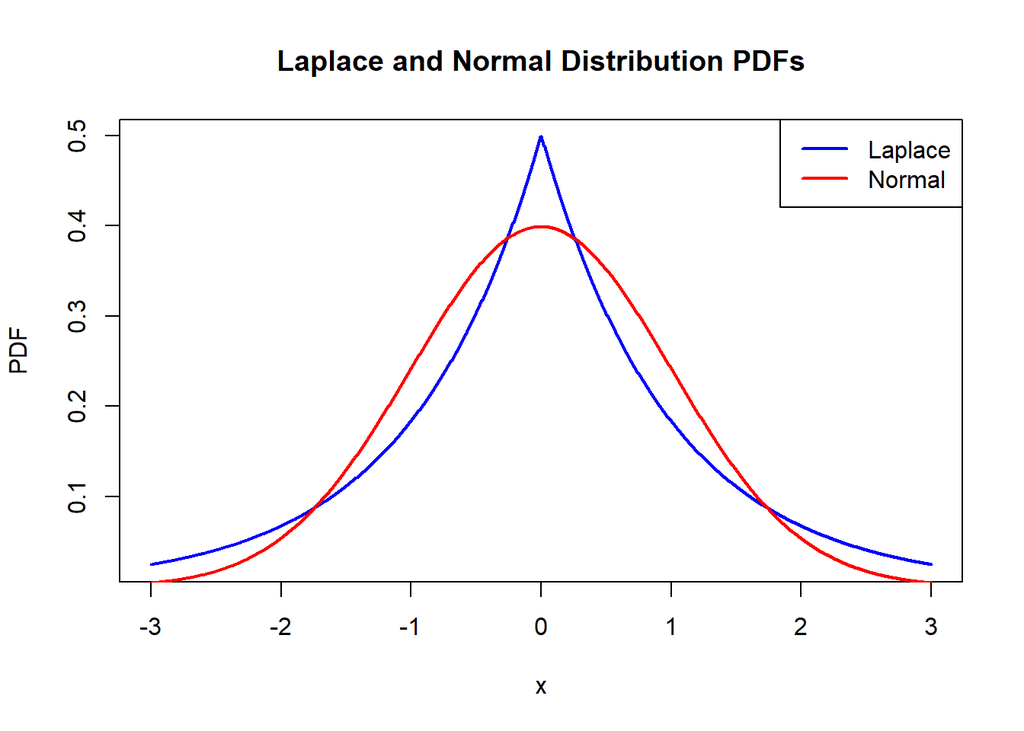

```r
# Parameters of the distributions
mu_laplace <- 0   # Laplace distribution: Location parameter
b_laplace <- 1    # Laplace distribution: Scale parameter

mu_normal <- 0    # Normal distribution: Mean
sd_normal <- 1    # Normal distribution: Standard deviation

# Generate x values
x <- seq(-3, 3, length.out = 1000)

# Calculate the Laplace PDF values for each x
laplace_pdf_values <- (1 / (2 * b_laplace)) * exp(-abs(x - mu_laplace) / b_laplace)

# Calculate the Normal PDF values for each x
normal_pdf_values <- dnorm(x, mean = mu_normal, sd = sd_normal)


# Create a line plot
plot(x, laplace_pdf_values, type = "l", lwd = 2, col = "blue",
     xlab = "x", ylab = "PDF", main = "Laplace and Normal Distribution PDFs")

# Add Normal distribution plot to the existing plot
lines(x, normal_pdf_values, type = "l", lwd = 2, col = "red")

# Add legend
legend("topright", legend = c("Laplace", "Normal"), col = c("blue", "red"), lwd = 2)
```

**Answer 3.d:**

The linear model using Laplace error noise is known to be more robust to outliers due to following reasons:

1. **Heavy Tails:** Laplace distribution has heavier tails, assigning higher probabilities to extreme values, reducing sensitivity to outliers.
2. **Resistant:** Laplace distribution’s slower decay away from mean makes it less influenced by extreme observations.
3. **Absolute Error Minimization:** Laplace minimizes absolute differences, less affected by outliers than Normal’s squared differences.
4. **Visual Comparison:** In the plot, Laplace’s fat tails and sharp peak show higher tolerance for extreme values.
5. **Robust Regression:** Laplace’s properties lead to stable parameter estimates in robust regression, unaffected by outliers.